# Workshop 4 - Multivariate regression in R [Solutions]

PART FOUR: CLASS EXERCISES ************************************* # 1. Use the ozone.data.csv datafile: # (a) use the datafile called airquality; # (b) explore the data to look at its structure, normality, linearity, heterogeneity; # (c) create coplots to look for interactions between the variables; # (d) create a multiplicative linear model to illustrate the what factors influences ozone levels in the city; # (e) Use model averaging to select the most parsimonious model; # (f) validate the ‘best’ model; # (g) create the predictive model and generate the regression equation.

# ozone.data.csv DATAFILE CONTENTS:

# Based on Daily readings of the following air quality values for May 1, 1973 (a Tuesday)

# to September 30, 1973 in New York.

# Response - ozone: Mean ozone in parts per billion from 1300 to 1500 hours at Roosevelt Island

# Explanatory - rad: Solar radiation in Langleys in the frequency band 4000–7700 Angstroms from 0800-1200 hours at Central Park

# Explanatory - wind: Average wind speed in miles per hour at 0700 and 1000 hours at LaGuardia Airport

# Explanatory - temp: Maximum daily temperature in degrees Fahrenheit at La Guardia Airport

Load your libraries

```r
library(tidyverse) # for wrangling
library(ggfortify)
library(car)
library(MuMIn)
```

# Load file (you already have the data!): File is ozone.data.csv

```r
Ozone <- read.csv(file.choose(), header = TRUE)
```

# look at data structure

```r
glimpse(Ozone)
```

```
Rows: 111
Columns: 4
$ rad   <int> 190, 118, 149, 313, 299, 99, 19, 256, 290, 274, 65, 334, 307, 78, 322, 44, 8, 320, 25, 92, 13, 252, 223, 279, 127, 291,…
$ temp  <int> 67, 72, 74, 62, 65, 59, 61, 69, 66, 68, 58, 64, 66, 57, 68, 62, 59, 73, 61, 61, 67, 81, 79, 76, 82, 90, 87, 82, 77, 72,…
$ wind  <dbl> 7.4, 8.0, 12.6, 11.5, 8.6, 13.8, 20.1, 9.7, 9.2, 10.9, 13.2, 11.5, 12.0, 18.4, 11.5, 9.7, 9.7, 16.6, 9.7, 12.0, 12.0, 1…
$ ozone <int> 41, 36, 12, 18, 23, 19, 8, 16, 11, 14, 18, 14, 34, 6, 30, 11, 1, 11, 4, 32, 23, 45, 115, 37, 29, 71, 39, 23, 21, 37, 20…
```

# Draw pictures to explore it….

# Boxplots - normality

```r
op <- par(mfrow = c(2,2))
boxplot(Ozone$ozone, ylab="Ozone")
boxplot(Ozone$rad, ylab = "Solar Radiation")
```

```r
boxplot(Ozone$wind, ylab = "Wind")
boxplot(Ozone$temp, ylab = "Temperature")
```

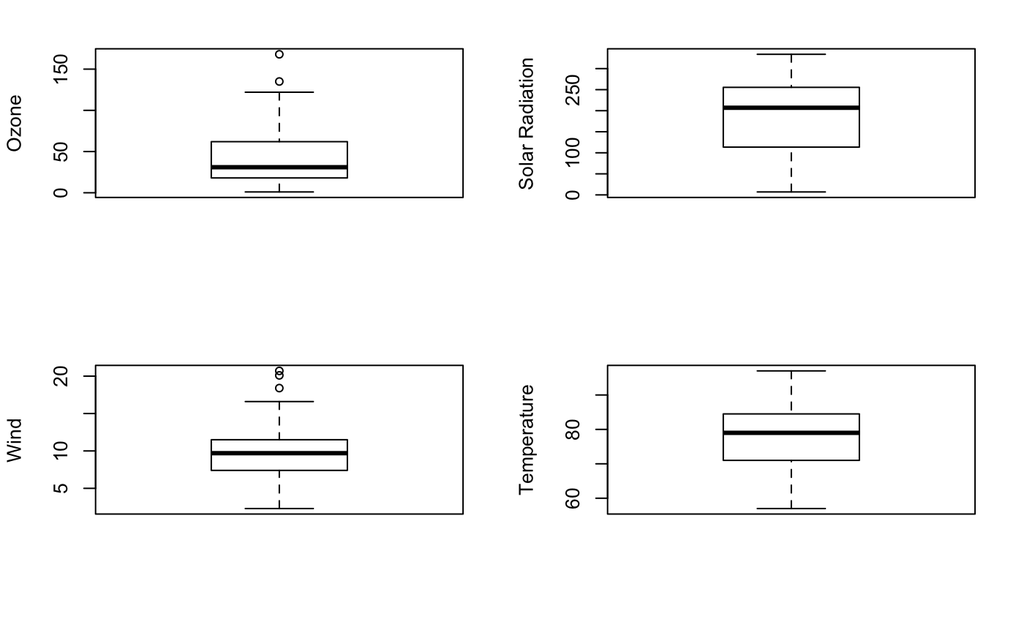

```r
par(op)
```

# Generally okay; wind and ozone have a few extreme values but it should be fine

# relationships between response and explanatories

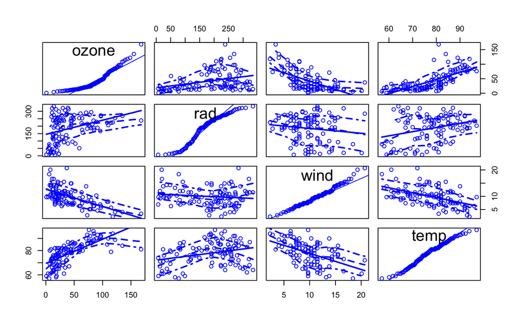

```r
scatterplotMatrix(~ozone + rad + wind + temp, data = Ozone, diagonal = list(method = "qqplot")) # use qqplot not boxplot
```

# Mixture of humped and linear x/Y relationships.

# Ozone ~ rad looks quadratic….ozone and rad slightly off normal.

# Might consider log10 transform if models are a mess.

# QQplots indicate that O2 and rad are a problem

# generate first full model using linear function. The full model uses all the interactions.

```r
M1 <- lm(ozone ~ rad * wind * temp, data = Ozone)
```

# look at summary

```r
summary(M1)
```

```
Call:
lm(formula = ozone ~ rad * wind * temp, data = Ozone)

Residuals:
    Min      1Q  Median      3Q     Max
-38.074 -11.194  -1.657   6.617  91.351

Coefficients:
                Estimate Std. Error t value Pr(>|t|)
(Intercept)   -7.131e+01  1.079e+02  -0.661    0.510
rad           -6.657e-01  5.871e-01  -1.134    0.260
wind           4.318e+00  8.881e+00   0.486    0.628
temp           1.347e+00  1.475e+00   0.913    0.363
rad:wind       3.403e-02  5.179e-02   0.657    0.513
rad:temp       1.099e-02  7.783e-03   1.412    0.161
wind:temp     -7.245e-02  1.254e-01  -0.578    0.565
rad:wind:temp -5.624e-04  6.999e-04  -0.804    0.423

Residual standard error: 19.19 on 103 degrees of freedom
Multiple R-squared:  0.6887,    Adjusted R-squared:  0.6675
F-statistic: 32.55 on 7 and 103 DF,  p-value: < 2.2e-16
```

# Nothing appears to be significant.

# need to simplify this a little….but first we need to check for inflationary values

# Note that any exponent will lead to inflation….

```r
vif(lm(ozone ~ rad * wind * temp, data = Ozone))
```

```
          rad          wind          temp      rad:wind      rad:temp     wind:temp rad:wind:temp
    855.78646     298.52903      59.00957    1112.86766     994.77835     285.41931    1159.32469
```

# but interaction terms are huge so remove the 3-way and largest 2-ways ones.

vif(lm(ozone ~ rad + wind + temp+ wind:temp, data = Ozone)) # Chuck out wind as it is huge leaving the interaction with wind and temp. # Our understanding how wind impacts temperature and ozone production suggests this is sensible.

```r
vif(lm(ozone ~ rad + temp + wind:temp, data = Ozone))
```

```
      rad      temp temp:wind
 1.095810  1.128567  1.031379
```

# no issues

```r
M2 <- lm(ozone ~ rad + temp + wind:temp, data = Ozone)
summary(M2)
```

```
Call:
lm(formula = ozone ~ rad + temp + wind:temp, data = Ozone)

Residuals:
    Min      1Q  Median      3Q     Max
-40.466 -13.694  -3.083  10.417  93.468

Coefficients:
              Estimate Std. Error t value Pr(>|t|)
(Intercept) -93.886295  18.474926  -5.082 1.60e-06 ***
rad           0.061314   0.022553   2.719  0.00765 **
temp          2.058589   0.218917   9.404 1.14e-15 ***
temp:wind    -0.046915   0.008094  -5.796 6.94e-08 ***
---
Signif. codes:  0 ‘***’ 0.001 ‘**’ 0.01 ‘*’ 0.05 ‘.’ 0.1 ‘ ’ 1

Residual standard error: 20.6 on 107 degrees of freedom
Multiple R-squared:  0.6273,    Adjusted R-squared:  0.6169
F-statistic: 60.04 on 3 and 107 DF,  p-value: < 2.2e-16
```

# validate

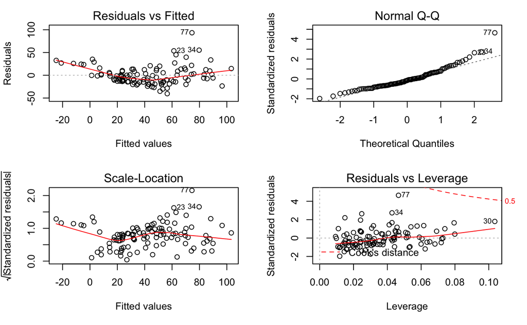

```r
op <- par(mfrow = c(2,2))
plot(M2)
par(op)
```

# ggfortify autoplot

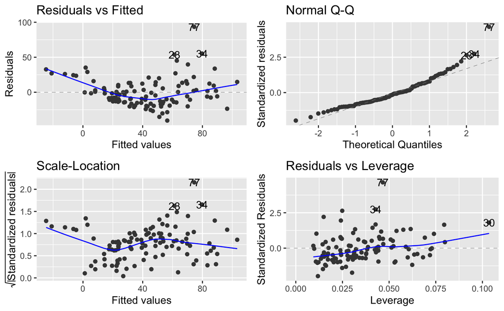

```r
autoplot(M2)
```

# It’s a mess…..heterogeneous residuals [see the clear wedge shape?] and not especially normally distributed

# Use MuMIn to sort out the modelling - note the options commmand must sit within the script window otherwise it will not work

```r
options(na.action=na.fail) # set options in Base R concerning missing values
M3 <- model.avg(dredge(M2, rank = "AICc")) # code introduces model.avg(), get.models and dredge functions
```

```
Fixed term is "(Intercept)"
```

```r
options(na.action = "na.omit") # reset base R options
summary(M3)
```

```
Call:
model.avg(object = dredge(M2, rank = "AICc"))

Component model call:
lm(formula = ozone ~ <6 unique rhs>, data = Ozone)

Component models:
       df  logLik    AICc  delta weight
123     5 -491.26  993.08   0.00   0.93
23      4 -494.96  998.30   5.22   0.07
12      4 -506.41 1021.20  28.11   0.00
2       3 -508.89 1024.00  30.92   0.00
1       3 -538.86 1083.94  90.85   0.00
(Null)  2 -546.04 1096.18 103.10   0.00

Term codes:
      rad      temp temp:wind
        1         2         3

Model-averaged coefficients:
(full average)
              Estimate Std. Error Adjusted SE z value Pr(>|z|)
(Intercept) -94.082620  18.524367   18.735795   5.022  5.1e-07 ***
rad           0.057114   0.026715    0.026918   2.122   0.0339 *
temp          2.070617   0.223123    0.225573   9.179  < 2e-16 ***
temp:wind    -0.046866   0.008113    0.008205   5.712  1.0e-08 ***

(conditional average)
              Estimate Std. Error Adjusted SE z value Pr(>|z|)
(Intercept) -94.082620  18.524367   18.735795   5.022 5.13e-07 ***
rad           0.061314   0.022553    0.022811   2.688  0.00719 **
temp          2.070617   0.223123    0.225573   9.179  < 2e-16 ***
temp:wind    -0.046867   0.008113    0.008205   5.712 1.10e-08 ***
---
Signif. codes:  0 ‘***’ 0.001 ‘**’ 0.01 ‘*’ 0.05 ‘.’ 0.1 ‘ ’ 1
```

# best models > 2 AICc includes ALL variables, so it is no different from the one above

# As a result the residuals are still a mess…

# AT THIS POINT WE MIGHT REFLECT ON HOW WE MODEL THESE DATA AND ADD IN SOME QUADRATICS AND MAYBE USE

# GENERALISED LINEAR APPROACHES, SUCH AS POISSON REGRESSION. BUT WE’LL COME ONTO THAT IN THE NEXT FEW WEEKS

# we go back to a linear model and transform the response

```r
M4 <- lm(log10(ozone) ~ rad + temp + wind:temp, data = Ozone)
summary(M4)
```

```
Call:
lm(formula = log10(ozone) ~ rad + temp + wind:temp, data = Ozone)

Residuals:
     Min       1Q   Median       3Q      Max
-0.89185 -0.13596 -0.00628  0.13618  0.52942

Coefficients:
              Estimate Std. Error t value Pr(>|t|)
(Intercept) -3.643e-01  1.960e-01  -1.858   0.0659 .
rad          1.103e-03  2.393e-04   4.610 1.12e-05 ***
temp         2.467e-02  2.323e-03  10.622  < 2e-16 ***
temp:wind   -3.641e-04  8.589e-05  -4.239 4.78e-05 ***
---
Signif. codes:  0 ‘***’ 0.001 ‘**’ 0.01 ‘*’ 0.05 ‘.’ 0.1 ‘ ’ 1

Residual standard error: 0.2185 on 107 degrees of freedom
Multiple R-squared:  0.6715,    Adjusted R-squared:  0.6622
F-statistic: 72.89 on 3 and 107 DF,  p-value: < 2.2e-16
```

# Validate the model

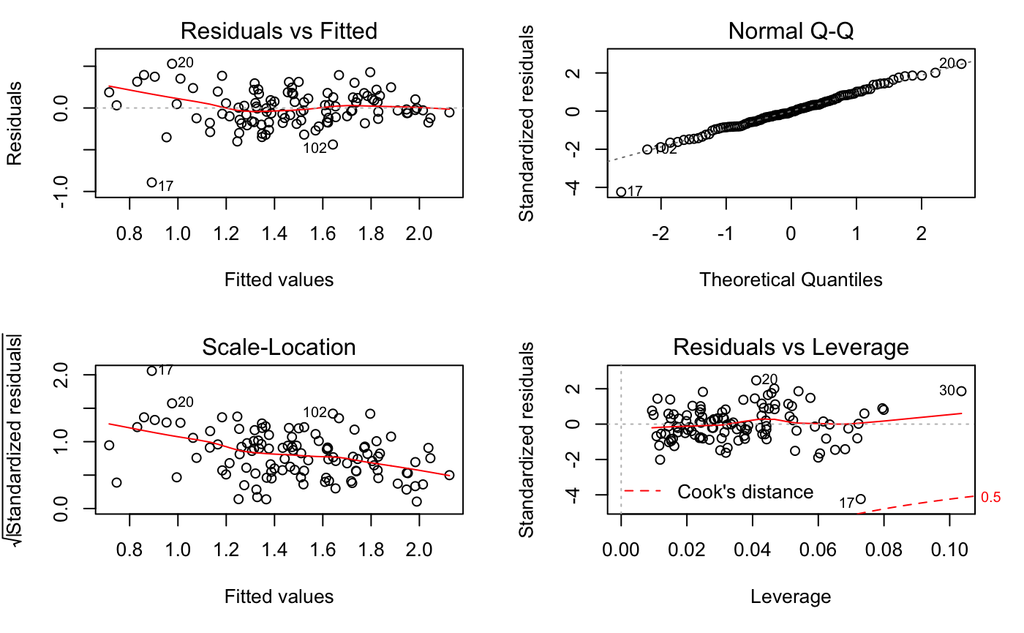

```r
op <- par(mfrow = c(2,2))
plot(M4)
par(op)
```